# 08 Practical ML - Course Project

Joe Nguyen

21 November 2015

# Executive Summary

This report aims to address how well people perform exercise activities. Specifically, it analyses data from accelerometers on the belt, forearm, arm and dumbell of six participants performing barbell lifts. The participants were instructed to perform lifts correctly and incorrectly in five different ways.

This report predicts the manner in which participants performed the lift, which is grouped into five classes (A to E). Information regarding the experiment (and classes) can be found at HAR website.

# Data Preprocessing

```r
# Download training and test sets
if (!dir.exists("./data")) { dir.create("./data") }
if (!file.exists("./data/pml-training.csv")) {
    urlTrain <- "https://d396qusza40orc.cloudfront.net/predmachlearn/pml-training.csv"
    urlTest <- "https://d396qusza40orc.cloudfront.net/predmachlearn/pml-testing.csv"
    download.file(urlTrain, "./data/pml-training.csv", method = "curl")
    download.file(urlTest, "./data/pml-testing.csv", method = "curl")
}
pmlData <- read.csv("./data/pml-training.csv")
submission <- read.csv("./data/pml-testing.csv")
dim(pmlData); dim(submission)
```

```
## [1] 19622   160
```

```
## [1]  20 160
```

We split the `pmlData` into training and testing sets. Because there is 19622 samples, we subset 30% of the dataset into training data for computational speed (5889 samples).

```r
library(caret); set.seed(12345)
idxTrain <- createDataPartition(pmlData$classe, p = 0.3, list = FALSE)
training <- pmlData[idxTrain,]; testing <- pmlData[-idxTrain,]
dim(training); dim(testing)
```

```
## [1] 5889  160
```

```
## [1] 13733   160
```

We examine the data using `str(training)` and clean the data. Unnecessary variables are removed, factor variables are converted to numeric, and variables with any NA are removed. Many variables with NA, including mean, variance, skewness etc …, were created by the research data’s authors for better feature selection. Instead, we perform machine learning on the raw measurements (Euler angles, acceleration, gyro, magnetometer).

```r
options(warn = -1)

clean_data <- function(data) {

    # Remove unnecessary variables
    data <- subset(data, select = -c(X, user_name, raw_timestamp_part_1, raw_timestamp_part_2, cvtd_timestamp, new_window, num_window))

    # Factor to numeric (except "classe" outcome)
    numVar <- ncol(data)
    idxRm <- rep(NA, numVar)
    for (i in 1 : (numVar-1)) {
        data[i] <- as.numeric(as.character(data[[i]]))

        # Omit vars will any NA (`table` shows many vars with NA have majority NA: 19216 vs 406)
        if (any(is.na(data[i]))) { idxRm[i] <- i }
    }
    idxRm <- na.omit(idxRm)
    data <- subset(data, select = -idxRm)
    return(data)
}

training <- clean_data(training)
testing <- clean_data(testing)
submission <- clean_data(submission)
```

# Exploratory Analysis

We explore using density plots for total acceleration. There is not a strong distinction among the `classe` labels. This property is also observed in the other variables (not plotted here), and suggests an intricate prediction method is required.

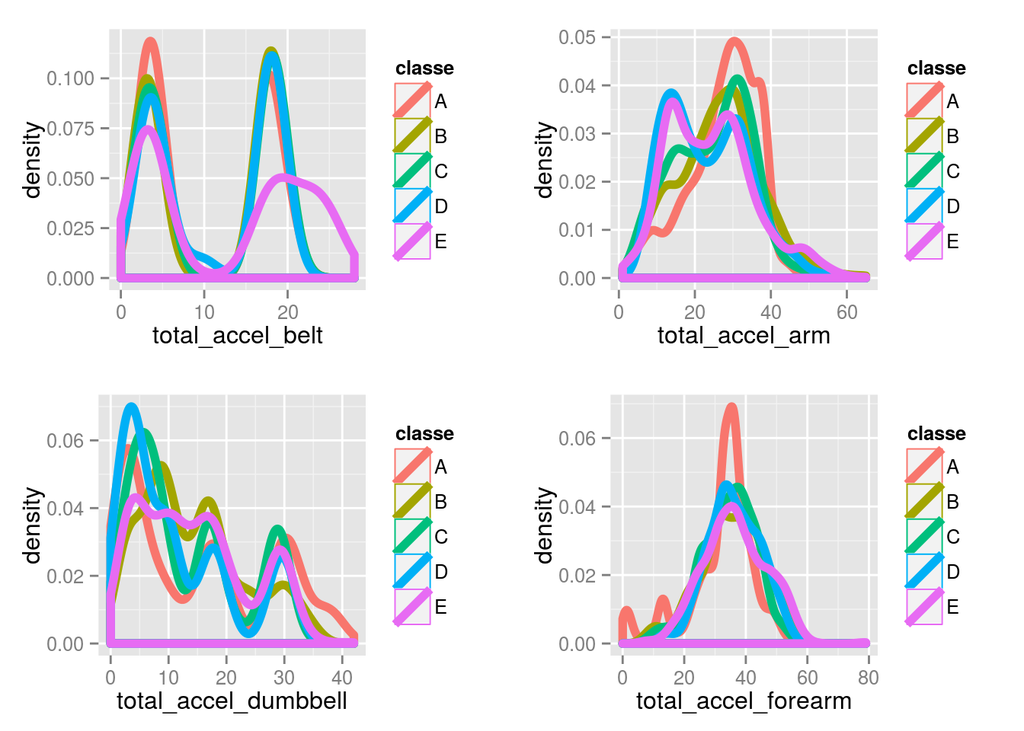

```r
library(ggplot2); library(gridExtra)
p1 <- ggplot(data = training, aes(x = total_accel_belt, col = classe)) +
    geom_density(size = 2)

p2 <- ggplot(data = training, aes(x = total_accel_arm, col = classe)) +
    geom_density(size = 2)

p3 <- ggplot(data = training, aes(x = total_accel_dumbbell, col = classe)) +
    geom_density(size = 2)

p4 <- ggplot(data = training, aes(x = total_accel_forearm, col = classe)) +
    geom_density(size = 2)
grid.arrange(p1,p2,p3,p4, ncol = 2)
```

# Model Building

We first use a classification tree with all variables as features to classify outcome `classe`, which contains labels A to E.

```r
modCt <- train(classe ~ ., method = "rpart", data = training)
modCtFinal <- modCt$finalModel

library(rattle)
```

[figure not shown]

```r
fancyRpartPlot(modCtFinal)
```

```r
predCt <- predict(modCt, newdata = testing)
confusionMatrix(testing$classe, predCt)
```

```
## Confusion Matrix and Statistics
##
##           Reference
## Prediction    A    B    C    D    E
##          A 3525   56  269    0   56
##          B 1098  904  655    0    0
##          C 1121   82 1192    0    0
##          D 1009  392  850    0    0
##          E  336  332  685    0 1171
##
## Overall Statistics
##
##                Accuracy : 0.4946
##                  95% CI : (0.4862, 0.503)
##     No Information Rate : 0.5162
##     P-Value [Acc > NIR] : 1
##
##                   Kappa : 0.3398
##  Mcnemar's Test P-Value : NA
##
## Statistics by Class:
##
##                      Class: A Class: B Class: C Class: D Class: E
## Sensitivity            0.4972  0.51189   0.3265       NA  0.95436
## Specificity            0.9427  0.85351   0.8807   0.8361  0.89181
## Pos Pred Value         0.9025  0.34023   0.4977       NA  0.46395
## Neg Pred Value         0.6373  0.92217   0.7831       NA  0.99500
## Prevalence             0.5162  0.12860   0.2659   0.0000  0.08935
## Detection Rate         0.2567  0.06583   0.0868   0.0000  0.08527
## Detection Prevalence   0.2844  0.19348   0.1744   0.1639  0.18379
## Balanced Accuracy      0.7200  0.68270   0.6036       NA  0.92309
```

We get rather lower accuracy (approx. 50%) using classification trees. In particular, class D is never identified. We turn to random forests (RFs) (bagging with trees) with 3-fold cross validation.

```r
modRf <- train(classe ~ ., method = "rf", data = training,
               trControl = trainControl(method = "cv", number = 3),
               proximity = TRUE)
modRfFinal <- modRf$finalModel; modRfFinal

# ** Unncessary with RF, but examine anyway since testing set exists **
predRf <- predict(modRf, newdata = testing)
confusionMatrix(testing$classe, predRf)

# Prediction on submission set (20 test cases for assignment submission)
predRfSub <- predict(modRf, newdata = submission)
```

Note: we have declared `eval=FALSE` here because Rmd has memory issues computing the model.